# Linear Progression Project

## import libraries and csv

```r
library(readr)
library(ggplot2)
library(plotly)
library(ggthemes)
library(dplyr)
bike <- read.csv('Training Exercises/Machine Learning Projects/CSV files for ML Projects/bikeshare.csv')
head(bike)
```

|  | datetime | season | holiday | workingday | weather | temp | atemp | humidity | windspeed | casual | registered | count |
| --- | --- | --- | --- | --- | --- | --- | --- | --- | --- | --- | --- | --- |
| 1 | 2011-01-01 00:00:00 | 1 | 0 | 0 | 1 | 9.84 | 14.395 | 81 | 0.0000 | 3 | 13 | 16 |
| 2 | 2011-01-01 01:00:00 | 1 | 0 | 0 | 1 | 9.02 | 13.635 | 80 | 0.0000 | 8 | 32 | 40 |
| 3 | 2011-01-01 02:00:00 | 1 | 0 | 0 | 1 | 9.02 | 13.635 | 80 | 0.0000 | 5 | 27 | 32 |
| 4 | 2011-01-01 03:00:00 | 1 | 0 | 0 | 1 | 9.84 | 14.395 | 75 | 0.0000 | 3 | 10 | 13 |
| 5 | 2011-01-01 04:00:00 | 1 | 0 | 0 | 1 | 9.84 | 14.395 | 75 | 0.0000 | 0 | 1 | 1 |
| 6 | 2011-01-01 05:00:00 | 1 | 0 | 0 | 2 | 9.84 | 12.880 | 75 | 6.0032 | 0 | 1 | 1 |

```r
tail(bike)
```

|  | datetime | season | holiday | workingday | weather | temp | atemp | humidity | windspeed | casual | registered | count |
| --- | --- | --- | --- | --- | --- | --- | --- | --- | --- | --- | --- | --- |
| 10881 | 2012-12-19 18:00:00 | 4 | 0 | 1 | 1 | 15.58 | 19.695 | 50 | 23.9994 | 23 | 546 | 569 |
| 10882 | 2012-12-19 19:00:00 | 4 | 0 | 1 | 1 | 15.58 | 19.695 | 50 | 26.0027 | 7 | 329 | 336 |
| 10883 | 2012-12-19 20:00:00 | 4 | 0 | 1 | 1 | 14.76 | 17.425 | 57 | 15.0013 | 10 | 231 | 241 |
| 10884 | 2012-12-19 21:00:00 | 4 | 0 | 1 | 1 | 13.94 | 15.910 | 61 | 15.0013 | 4 | 164 | 168 |
| 10885 | 2012-12-19 22:00:00 | 4 | 0 | 1 | 1 | 13.94 | 17.425 | 61 | 6.0032 | 12 | 117 | 129 |
| 10886 | 2012-12-19 23:00:00 | 4 | 0 | 1 | 1 | 13.12 | 16.665 | 66 | 8.9981 | 4 | 84 | 88 |

```r
summary(bike)
```

```
                datetime         season         holiday          workingday
 2011-01-01 00:00:00:    1   Min.   :1.000   Min.   :0.00000   Min.   :0.0000
 2011-01-01 01:00:00:    1   1st Qu.:2.000   1st Qu.:0.00000   1st Qu.:0.0000
 2011-01-01 02:00:00:    1   Median :3.000   Median :0.00000   Median :1.0000
 2011-01-01 03:00:00:    1   Mean   :2.507   Mean   :0.02857   Mean   :0.6809
 2011-01-01 04:00:00:    1   3rd Qu.:4.000   3rd Qu.:0.00000   3rd Qu.:1.0000
 2011-01-01 05:00:00:    1   Max.   :4.000   Max.   :1.00000   Max.   :1.0000
 (Other)            :10880
    weather           temp           atemp          humidity        windspeed
 Min.   :1.000   Min.   : 0.82   Min.   : 0.76   Min.   :  0.00   Min.   : 0.000
 1st Qu.:1.000   1st Qu.:13.94   1st Qu.:16.66   1st Qu.: 47.00   1st Qu.: 7.002
 Median :1.000   Median :20.50   Median :24.24   Median : 62.00   Median :12.998
 Mean   :1.418   Mean   :20.23   Mean   :23.66   Mean   : 61.89   Mean   :12.799
 3rd Qu.:2.000   3rd Qu.:26.24   3rd Qu.:31.06   3rd Qu.: 77.00   3rd Qu.:16.998
 Max.   :4.000   Max.   :41.00   Max.   :45.45   Max.   :100.00   Max.   :56.997

     casual         registered        count
 Min.   :  0.00   Min.   :  0.0   Min.   :  1.0
 1st Qu.:  4.00   1st Qu.: 36.0   1st Qu.: 42.0
 Median : 17.00   Median :118.0   Median :145.0
 Mean   : 36.02   Mean   :155.6   Mean   :191.6
 3rd Qu.: 49.00   3rd Qu.:222.0   3rd Qu.:284.0
 Max.   :367.00   Max.   :886.0   Max.   :977.0
```

```r
numBike <- sapply(bike,is.numeric)
cor(bike[numBike])
```

```
                 season       holiday   workingday      weather          temp
season      1.000000000  0.0293676097 -0.008126058  0.008878651  0.2586885508
holiday     0.029367610  1.0000000000 -0.250491391 -0.007073912  0.0002946034
workingday -0.008126058 -0.2504913912  1.000000000  0.033771842  0.0299655472
weather     0.008878651 -0.0070739115  0.033771842  1.000000000 -0.0550354182
temp        0.258688551  0.0002946034  0.029965547 -0.055035418  1.0000000000
atemp       0.264744326 -0.0052147782  0.024660329 -0.055375973  0.9849481105
humidity    0.190610020  0.0019287112 -0.010879845  0.406243651 -0.0649487709
windspeed  -0.147121209  0.0084087378  0.013373313  0.007261124 -0.0178520099
casual      0.096758063  0.0437989287 -0.319110963 -0.135917680  0.4670970641
registered  0.164010534 -0.0209556729  0.119459851 -0.109340372  0.3185712803
count       0.163439017 -0.0053929845  0.011593866 -0.128655201  0.3944536450
                  atemp     humidity    windspeed      casual  registered        count
season      0.264744326  0.190610020 -0.147121209  0.09675806  0.16401053  0.163439017
holiday    -0.005214778  0.001928711  0.008408738  0.04379893 -0.02095567 -0.005392984
workingday  0.024660329 -0.010879845  0.013373313 -0.31911096  0.11945985  0.011593866
weather    -0.055375973  0.406243651  0.007261124 -0.13591768 -0.10934037 -0.128655201
temp        0.984948110 -0.064948771 -0.017852010  0.46709706  0.31857128  0.394453645
atemp       1.000000000 -0.043535709 -0.057473002  0.46206654  0.31463539  0.389784437
humidity   -0.043535709  1.000000000 -0.318606992 -0.34818690 -0.26545787 -0.317371479
windspeed  -0.057473002 -0.318606992  1.000000000  0.09227619  0.09105166  0.101369470
casual      0.462066536 -0.348186899  0.092276189  1.00000000  0.49724969  0.690413565
registered  0.314635386 -0.265457868  0.091051662  0.49724969  1.00000000  0.970948106
count       0.389784437 -0.317371479  0.101369470  0.69041357  0.97094811  1.000000000
```

## Can you figure out what is the target we are trying to predict?

The target would be the count variable. That is, the number of bicycles used. This would be useful for the people who run a bike rental scheme - they would want to know what the demand is for their product at different times, in different places, so they can purchase the right number of bicycles.

## Exploratory Data Analysis

Create a scatter plot of count vs temp. Set a good alpha value.

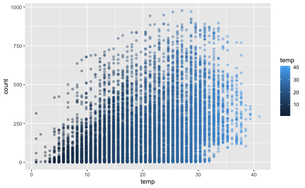

```r
ggplot(bike, aes(x=temp, y=count, color=temp)) + geom_point(alpha=0.4)
```

## Plot count versus datetime as a scatterplot with a color gradient based on temperature. You’ll need to convert the datetime column into POSIXct before plotting.

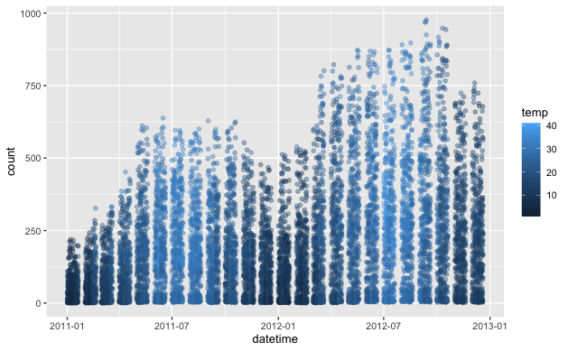

```r
bike <- bike %>% mutate(datetime=as.POSIXct(datetime))
#head(bike)
ggplot(bike, aes(x=datetime, y=count, color=temp)) + geom_point(alpha=0.4)
```

What is the correlation between temp and count?

```r
cor(bike$temp, bike$count)
```

```
[1] 0.3944536
```

Let’s explore the season data. Create a boxplot, with the y axis indicating count and the x axis begin a box for each season.

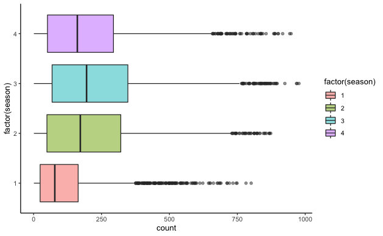

```r
ggplot(bike, aes(x=factor(season), y=count)) + geom_boxplot(aes(fill=factor(season)),alpha=0.5) + coord_flip() + theme_classic()
```

```r
# use coord_flip to flip the axes
# carBox <- ggplot(carData,aes(x=factor(cyl),y=mpg)) + geom_boxplot(aes(fill=factor(cyl))) + coord_flip() + theme_linedraw()
# carBox
```

## Feature Engineering

A lot of times you’ll need to use domain knowledge and experience to engineer and create new features. Let’s go ahead and engineer some new features from the datetime column.

Create an “hour” column that takes the hour from the datetime column. You’ll probably need to apply some function to the entire datetime column and reassign it. Hint:

time.stamp <- bike$datetime[4] format(time.stamp, “%H”)

```r
bike <- bike %>% mutate(hour=format(datetime, "%H"))
head(bike)
```

|  | datetime | season | holiday | workingday | weather | temp | atemp | humidity | windspeed | casual | registered | count | hour |
| --- | --- | --- | --- | --- | --- | --- | --- | --- | --- | --- | --- | --- | --- |
| 1 | 2011-01-01 00:00:00 | 1 | 0 | 0 | 1 | 9.84 | 14.395 | 81 | 0.0000 | 3 | 13 | 16 | 00 |
| 2 | 2011-01-01 01:00:00 | 1 | 0 | 0 | 1 | 9.02 | 13.635 | 80 | 0.0000 | 8 | 32 | 40 | 01 |
| 3 | 2011-01-01 02:00:00 | 1 | 0 | 0 | 1 | 9.02 | 13.635 | 80 | 0.0000 | 5 | 27 | 32 | 02 |
| 4 | 2011-01-01 03:00:00 | 1 | 0 | 0 | 1 | 9.84 | 14.395 | 75 | 0.0000 | 3 | 10 | 13 | 03 |
| 5 | 2011-01-01 04:00:00 | 1 | 0 | 0 | 1 | 9.84 | 14.395 | 75 | 0.0000 | 0 | 1 | 1 | 04 |
| 6 | 2011-01-01 05:00:00 | 1 | 0 | 0 | 2 | 9.84 | 12.880 | 75 | 6.0032 | 0 | 1 | 1 | 05 |

## Now create a scatterplot of count versus hour, with color scale based on temp. Only use bike data where workingday==1.

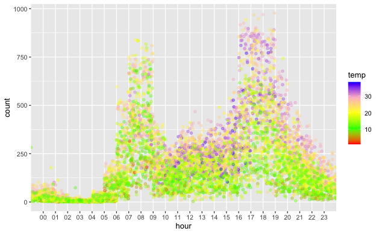

```r
bike2 <- bike %>% filter(workingday==1)

myColors <- c('red', 'green', 'yellow', 'pink', 'blue')

ggplot(bike2, aes(x=hour, y=count,color=temp)) + geom_point(alpha=0.4, position = position_jitter(w=1,h=0)) + scale_color_gradientn(colors=myColors)
```

```r
NA
NA
NA
NA
```

Optional Additions:

Use the additional layer: scale_color_gradientn(colors=c(‘color1’,color2,etc..)) where the colors argument is a vector gradient of colors you choose, not just high and low. Use position=position_jitter(w=1, h=0) inside of geom_point() and check out what it does.

Now create the same plot for non working days:

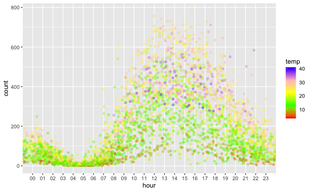

```r
bike3 <- bike %>% filter(workingday==0)
ggplot(bike3, aes(x=hour, y=count,color=temp)) + geom_point(alpha=0.4, position=position_jitter(w=1,h=0)) + scale_color_gradientn(colors=myColors)
```

Building the Model Use lm() to build a model that predicts count based solely on the temp feature, name it temp.model

```r
tempModel <- lm(count ~ temp, data=bike)
```

Get the summary of the temp.model

```r
summary(tempModel)
```

```
Call:
lm(formula = count ~ temp, data = bike)

Residuals:
    Min      1Q  Median      3Q     Max
-293.32 -112.36  -33.36   78.98  741.44

Coefficients:
            Estimate Std. Error t value Pr(>|t|)
(Intercept)   6.0462     4.4394   1.362    0.173
temp          9.1705     0.2048  44.783   <2e-16 ***
---
Signif. codes:  0 ‘***’ 0.001 ‘**’ 0.01 ‘*’ 0.05 ‘.’ 0.1 ‘ ’ 1

Residual standard error: 166.5 on 10884 degrees of freedom
Multiple R-squared:  0.1556,    Adjusted R-squared:  0.1555
F-statistic:  2006 on 1 and 10884 DF,  p-value: < 2.2e-16
```

## How many bike rentals would we predict if the temperature was 25 degrees Celsius? Calculate this two ways:

Using the values we just got above Using the predict() function

```r
myWay <- 6.0462+(25 * 9.1705)
myWay
```

```
[1] 235.3087
```

```r
temp.test <- data.frame(temp=c(25))

highWay <- predict(tempModel, temp.test)
highWay
```

```
       1
235.3097
```

## Use sapply() and as.numeric to change the hour column to a column of numeric values.

```r
bike$hour <- sapply(bike$hour,as.numeric)
head(bike)
```

[output not shown]

## Finally build a model that attempts to predict count based off of the following features. Figure out if theres a way to not have to pass/write all these variables into the lm() function. Hint: StackOverflow or Google may be quicker than the documentation.

season holiday workingday weather temp humidity windspeed hour (factor)

```r
model <- lm(count ~ . -casual - registered -datetime -atemp,bike )
```

Get the summary of the model

```r
summary(model)
```

[output not shown]